# APM - HW 3

Brian Bates, Zach Dorflinger, Kristina Paterson, Chris Stocks

2/13/2020

### Question 1

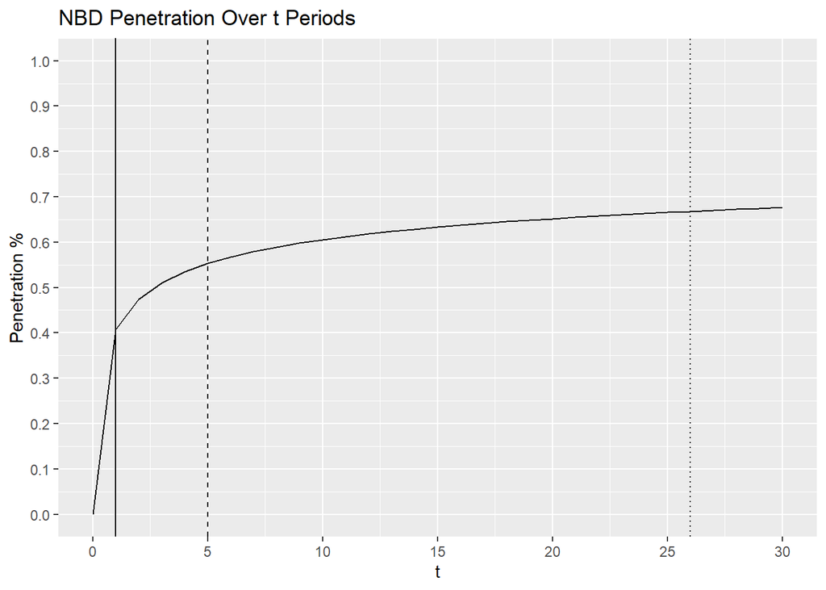

```r
#create given parameter estimate table
NBD_cof <- data.frame("r" = .181, "a" = .059)
NBD_HCNB_cof <- data.frame("r" = .181, "a" = .059, "pi" = .551)

#penetration for NBD
pen <- function(r, a, t) {
    return(1 - (a/(a+t))^r)
}

#penetration for HCNB
pen_HCNB <- function(r, a, t, pi) {
    return(((1-pi ) * (1 - (a/(a+t))^r)))
}

t_list <- seq(0,30,1)

#1a
NBD_penetration_1 <- pen(r = NBD_cof$r, a = NBD_cof$a, t=1)
NBD_penetration_5 <- pen(r = NBD_cof$r, a = NBD_cof$a, t=5)
NBD_penetration_26 <- pen(r = NBD_cof$r, a = NBD_cof$a, t=26)

NBD_penetration <- as.data.frame(pen(r = NBD_cof$r, a = NBD_cof$a, t=t_list))
NBD_penetration_graph <- add_column(NBD_penetration, t_list) %>%
    rename('Penetration' = 1)

NBD_penetration_graph %>%
    ggplot(aes(x=t_list, y=Penetration)) +
    geom_line() +
    scale_x_continuous(expression("t"), breaks=seq(0,30,5)) +
    scale_y_continuous(expression("Penetration %"), breaks=seq(0,1,.1), limits = c(0,1)) +
    ggtitle('NBD Penetration Over t Periods') +
    geom_vline(xintercept=1, linetype=1) +
    geom_vline(xintercept=5, linetype=2) +
    geom_vline(xintercept=26, linetype=3)
```

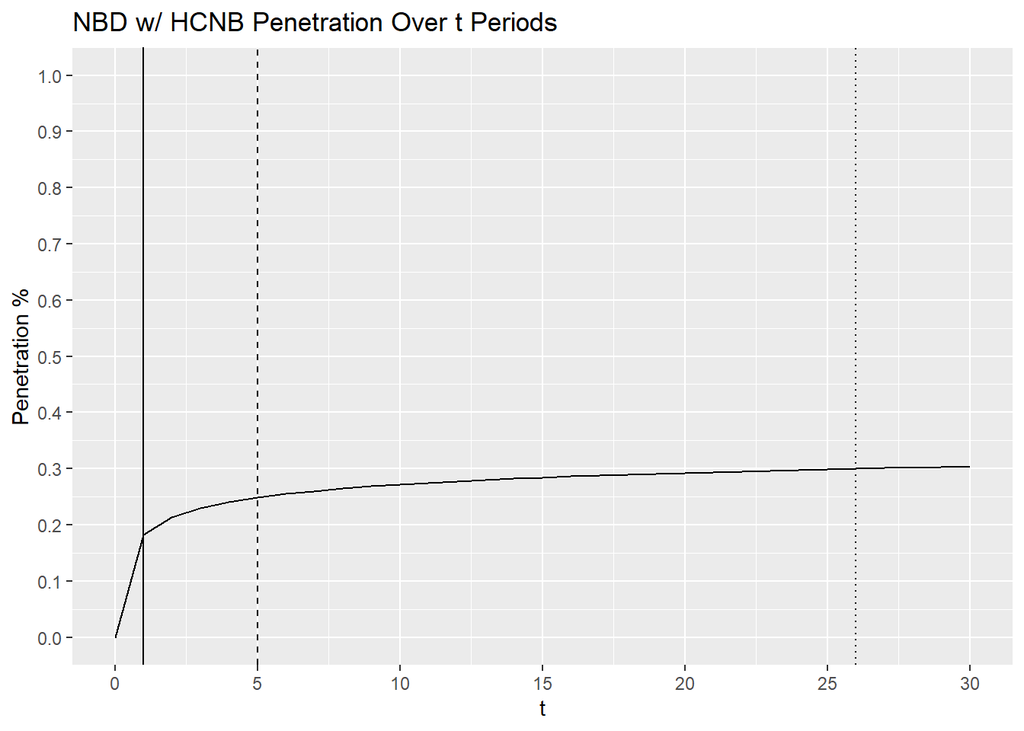

```r
NBD_HCNB_penetration_1 <- pen_HCNB(r = NBD_HCNB_cof$r, a = NBD_HCNB_cof$a, t=1, pi=.551)
NBD_HCNB_penetration_5 <- pen_HCNB(r = NBD_HCNB_cof$r, a = NBD_HCNB_cof$a, t=5, pi=.551)
NBD_HCNB_penetration_26 <- pen_HCNB(r = NBD_HCNB_cof$r, a = NBD_HCNB_cof$a, t=26, pi=.551)

NBD_HCNB_penetration <- as.data.frame(pen_HCNB(r = NBD_HCNB_cof$r, a = NBD_HCNB_cof$a, t=t_list, pi=NBD_HCNB_cof$pi))
NBD_HCNB_penetration_graph <- add_column(NBD_HCNB_penetration, t_list) %>%
    rename('Penetration' = 1)

NBD_HCNB_penetration_graph %>%
    ggplot(aes(x=t_list, y=Penetration)) +
    geom_line() +
    scale_x_continuous(expression("t"), breaks=seq(0,30,5)) +
    scale_y_continuous(expression("Penetration %"), breaks=seq(0,1,.1), limits = c(0,1)) +
    ggtitle('NBD w/ HCNB Penetration Over t Periods') +
    geom_vline(xintercept=1, linetype=1) +
    geom_vline(xintercept=5, linetype=2) +
    geom_vline(xintercept=26, linetype=3)
```

#### 1A)

The NBD model predicts:

- 40.7% penetration after 1 period
- 55.3% penetration after 5 periods
- 66.8% penetration after 26 periods

The NBD with HCNB model predicts:

- 18.3% penetration after 1 period
- 24.8% penetration after 5 periods
- 30% penetration after 26 periods

#### 1B)

I would tell my manager to expect a maximum penetration of 45%, because if 55% of the population is a hard core never buyer, than we can never increase above that threshold.

### Question 2

```r
nbd_prob <- function(x, r, a, t) {
    (gamma(r + x) / (gamma(r) * factorial(x))) *
        ((a / (a + t))^r) *
        ((t / (a + t))^x)
}

# Custom log likelihood function for #2
ll_nbd_2 <- function(pars, resp_vector, t) {
    r <- pars[1]
    a <- pars[2]

    probs <- rep(NA, 5)
    probs[1] <- nbd_prob(0, r, a, t)
    probs[2] <- nbd_prob(1, r, a, t)
    probs[3] <- nbd_prob(2, r, a, t)
    probs[4] <- nbd_prob(3, r, a, t) + nbd_prob(4, r, a, t) + nbd_prob(5, r, a, t)
    prob_under6 <- sum(probs, na.rm = T)
    probs[5] <- 1 - prob_under6

    ll <- sum(log(probs) * resp_vector)
    return(-ll)
}

# Responses vector from HW#2
responses <- c(1020, 166, 270, 279, 130)

# Optimization
pars = c(.5, .5)
opt_nbd_2 <- optim(pars, fn = ll_nbd_2, resp_vector = responses, t = 1)

# Predictions for x:0-10
pred_data <- data.frame(x=0:10)
pred_data$pred <- nbd_prob(pred_data$x, opt_nbd_2$par[1], opt_nbd_2$par[2], 1) * sum(responses)

kable(pred_data) %>%
    kable_styling(full_width = FALSE, bootstrap_options = c("striped", "hover"))
```

| x | pred |
| --- | --- |
| 0 | 990.6 |
| 1 | 310.7 |
| 2 | 173.2 |
| 3 | 110.7 |
| 4 | 75.2 |
| 5 | 52.9 |
| 6 | 38.1 |
| 7 | 27.9 |
| 8 | 20.6 |
| 9 | 15.4 |
| 10 | 11.6 |

Parameter estimates:

- r: 0.391
- a: 0.248
- Avg surveys: 1.6

###3

```r
data <- read.csv("./khakichinos.txt", header = T, sep = "") %>%
    select(c(ID, Visits))

# From slide 21
nbd_prob <- function(x, r, a, t) {
    (gamma(r + x) / (gamma(r) * factorial(x))) *
        ((a / (a + t))^r) *
        ((t / (a + t))^x)
}

# Custom log likelihood function for #3
ll_nbd_3 <- function(pars, x_vector, t) {
    r <- pars[1]
    a <- pars[2]

    prob_vector <- nbd_prob(x_vector, r, a, t)

    ll <- sum(log(prob_vector))
    return(-ll)
}

# Estimate model
pars = c(.5, .5)
opt_nbd_3 <- optim(pars, fn = ll_nbd_3, x_vector = data$Visits, t = 1)

# Parameter interpretation
r <- opt_nbd_3$par[1]
a <- opt_nbd_3$par[2]
exp_x <- r/a

# Reach function
reach <- function(r, a, t) {
    1 - ((a/(a + t))^r)
}

# Reach for x:0-36
reach_data <- data.frame(t=0:36)
reach_data$reach <- reach(r, a, reach_data$t) * 100
```

#### A)

The parameters of the fitted NBD model (r: 0.134, a: 0.141) imply that a large portion of the internet users in the data will not visit (or will virtually never visit) khakichinos.com. A relatively small portion of the userbase will visit the site many times.

#### B)

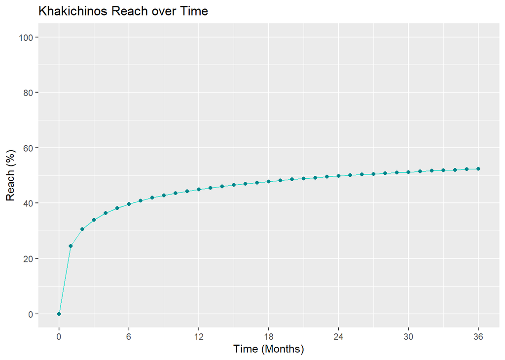

```r
# Plot it
ggplot(data = reach_data, aes(x = t, y = reach)) +
    geom_line(color = "turquoise") +
    geom_point(color = "turquoise4") +
    scale_y_continuous(name = "Reach (%)", breaks = seq(0, 100, 20), limits = c(0, 100)) +
    scale_x_continuous(name = "Time (Months)", breaks = seq(0, 36, 6), limits = c(0, 36)) +
    ggtitle("Khakichinos Reach over Time")
```

```r
# Value at 12
v12 <- reach_data[13, "reach"]
```

At 12 periods, an expected 44.9% of potential users will have visited khakichinos.com at least once.

###4

4a.

$E(\lambda) = \frac{r}{α}$

4b. Prior = $g(\lambda | r,a) = \frac{a^r}{\gamma(r)}\lambda^{r-1}e^{-a\lambda}$

Conditional Likelihood = $P(X(T) = x | \lambda) = \frac{(\lambda T)^{x}e^{-\lambda T}}{x!}$

Marginal Likelihood = $\frac{\gamma (r+x)}{\gamma(r)x!}(\frac{a}{a+T})^r(\frac{T}{a+T})^x$

$Posterior = Prior\frac{Conditional}{Marginal}$

Posterior = $\frac{(a+T)^{r+x}}{\gamma(r+x)}\lambda^{r-1+x}e^{-(a\lambda + T\lambda)}$

Bayes update: add $T$ to $a$ and add $x$ to $r$

4c.

```r
kc_data <- data.frame(
  User = c('A','B','C','D','E'),
  Month1 = c(0,2,0,0,6),
  Month2=c(0,0,5,0,5),
  Month3=c(0,0,4,1,4),
  Month4=c(0,0,0,0,0),
  Month5=c(0,0,0,0,0),
  Month6=c(0,0,0,0,0),
  Month7=c(0,0,0,0,0))



for (i in 5:8) {
  for(j in 1:nrow(kc_data)){
    kc_data[j,i] <- (r+sum(kc_data[j,2:4]))/(a+3)
  }
}

kc_data <- kc_data %>% mutate(Month6and7 = kc_data$Month6 + kc_data$Month7)
kc_data <- kc_data[,c(1:6,9)]

kable(kc_data) %>%
    kable_styling(full_width = FALSE, bootstrap_options = c("striped", "hover"))
```

| User | Month1 | Month2 | Month3 | Month4 | Month5 | Month6and7 |
| --- | --- | --- | --- | --- | --- | --- |
| A | 0 | 0 | 0 | 0.043 | 0.043 | 0.085 |
| B | 2 | 0 | 0 | 0.679 | 0.679 | 1.359 |
| C | 0 | 5 | 4 | 2.908 | 2.908 | 5.816 |
| D | 0 | 0 | 1 | 0.361 | 0.361 | 0.722 |
| E | 6 | 5 | 4 | 4.818 | 4.818 | 9.636 |